# Predicting Liked Songs

Riley Zamora

2023-03-16

# Introduction

The goal of this project is to create a classification model that uses song data from Spotify and can predict whether a person likes a song or not.

## Spotify

[figure not shown]

Spotify is an audio streaming and media services platform. The company has over 100 million songs available on their platform, and even better they have specific data on each-and-every song. My model will be able to look at any song’s data and predict whether it is liked.

## What Determines whether a Song is liked?

In this project, the dataset titled [‘Spotify Recommendation’](https://www.kaggle.com/datasets/bricevergnou/spotify-recommendation), posted on Kaggle by Brice Vergnou, consists of 195 songs from Spotify, with 100 labeled as liked songs and 95 as disliked songs. However, my original idea was to compile and create a data set myself using Spotify’s data to be to predict what music I like. When all is said and done, I may still pursue this idea.

## Why?

Music has been around arguably as long as people have. There is always new music being released and if I could predict which of these new songs I like I would always have an updated playlist and never get sick of listening to the same music all the time.

# Loading Packages

```r
# Loading all necessary packages
library(tidyverse)
library(dplyr)
library(tidymodels)
library(readr)
library(kknn)
library(janitor)
library(ISLR)
library(ISLR2)
library(discrim)
library(poissonreg)
library(glmnet)
library(corrr)
library(corrplot)
library(randomForest)
library(ggplot2)
library(kableExtra)
library(vip)
library(rpart)
library(rpart.plot)
library(parsnip)
tidymodels_prefer()
```

# Raw Data

## Load in the Data

```r
# Assigning the data
spotify <- read_csv('C:/Users/riley/Downloads/data-3/data.csv')
```

*This dataset is titled [`Spotify Recommendation`](https://www.kaggle.com/datasets/bricevergnou/spotify-recommendation) posted on kaggle.com by Brice Vergnou.*

## Variables

```r
head(spotify)
```

```
## # A tibble: 6 × 14
##   danceabil…¹ energy   key loudn…²  mode speec…³ acous…⁴ instr…⁵ liven…⁶ valence
##         <dbl>  <dbl> <dbl>   <dbl> <dbl>   <dbl>   <dbl>   <dbl>   <dbl>   <dbl>
## 1       0.803 0.624      7   -6.76     0  0.0477  0.451  7.34e-4  0.1     0.628
## 2       0.762 0.703     10   -7.95     0  0.306   0.206  0        0.0912  0.519
## 3       0.261 0.0149     1  -27.5      1  0.0419  0.992  8.97e-1  0.102   0.0382
## 4       0.722 0.736      3   -6.99     0  0.0585  0.431  1.18e-6  0.123   0.582
## 5       0.787 0.572      1   -7.52     1  0.222   0.145  0        0.0753  0.647
## 6       0.778 0.632      8   -6.42     1  0.125   0.0404 0        0.0912  0.827
## # … with 4 more variables: tempo <dbl>, duration_ms <dbl>,
## #   time_signature <dbl>, liked <dbl>, and abbreviated variable names
## #   ¹danceability, ²loudness, ³speechiness, ⁴acousticness, ⁵instrumentalness,
## #   ⁶liveness
```

There are 195 rows/observations and 14 columns where each column is a variable. See the codebook for a description of each variable. We are going to predict the variable `liked`, 0 for disliked 1 for liked. We could potentially use all 13 variables to predict our response `liked` but that *could* lead to over fitting so we will definitely run checks to find the best model.

# Exploratory Data Analysis

Lets take a look at the data to see what predictors might be useful and get a general idea of what we are going to be working with.

## Missing Values

First and foremost, we must check that our data has no missing values. To do this, we will run `summary()`.

```r
spotify %>%
  summary()
```

```
##   danceability        energy            key            loudness
##  Min.   :0.1300   Min.   :0.0024   Min.   : 0.000   Min.   :-42.261
##  1st Qu.:0.4625   1st Qu.:0.5335   1st Qu.: 2.000   1st Qu.: -9.962
##  Median :0.7050   Median :0.6590   Median : 6.000   Median : -7.766
##  Mean   :0.6367   Mean   :0.6384   Mean   : 5.497   Mean   : -9.482
##  3rd Qu.:0.7990   3rd Qu.:0.8375   3rd Qu.: 8.000   3rd Qu.: -5.829
##  Max.   :0.9460   Max.   :0.9960   Max.   :11.000   Max.   : -2.336
##       mode         speechiness      acousticness      instrumentalness
##  Min.   :0.0000   Min.   :0.0278   Min.   :0.000003   Min.   :0.0000000
##  1st Qu.:0.0000   1st Qu.:0.0568   1st Qu.:0.042200   1st Qu.:0.0000000
##  Median :1.0000   Median :0.0962   Median :0.213000   Median :0.0000076
##  Mean   :0.5385   Mean   :0.1490   Mean   :0.319093   Mean   :0.1923373
##  3rd Qu.:1.0000   3rd Qu.:0.2305   3rd Qu.:0.504000   3rd Qu.:0.0975000
##  Max.   :1.0000   Max.   :0.5400   Max.   :0.995000   Max.   :0.9690000
##     liveness         valence           tempo         duration_ms
##  Min.   :0.0331   Min.   :0.0353   Min.   : 60.17   Min.   : 77203
##  1st Qu.:0.0840   1st Qu.:0.2690   1st Qu.:100.24   1st Qu.:178301
##  Median :0.1050   Median :0.5250   Median :124.90   Median :204000
##  Mean   :0.1485   Mean   :0.4936   Mean   :121.09   Mean   :213409
##  3rd Qu.:0.1770   3rd Qu.:0.7175   3rd Qu.:142.46   3rd Qu.:242374
##  Max.   :0.6330   Max.   :0.9800   Max.   :180.04   Max.   :655213
##  time_signature      liked
##  Min.   :1.000   Min.   :0.0000
##  1st Qu.:4.000   1st Qu.:0.0000
##  Median :4.000   Median :1.0000
##  Mean   :3.913   Mean   :0.5128
##  3rd Qu.:4.000   3rd Qu.:1.0000
##  Max.   :5.000   Max.   :1.0000
```

We have no missing data! This is what I expected because our data is collected by Spotify for this very purpose. Spotify uses machine learning to recommend songs to their users. If they had holes in their data, they would risk running a poor service and likely recommend songs that people do not like.

## Factor variables

We need to make sure that any variables with specific levels are factorized.

```r
str(spotify)
```

```
## spc_tbl_ [195 × 14] (S3: spec_tbl_df/tbl_df/tbl/data.frame)
##  $ danceability    : num [1:195] 0.803 0.762 0.261 0.722 0.787 0.778 0.666 0.922 0.794 0.853 ...
##  $ energy          : num [1:195] 0.624 0.703 0.0149 0.736 0.572 0.632 0.589 0.712 0.659 0.668 ...
##  $ key             : num [1:195] 7 10 1 3 1 8 0 7 7 3 ...
##  $ loudness        : num [1:195] -6.76 -7.95 -27.53 -6.99 -7.52 ...
##  $ mode            : num [1:195] 0 0 1 0 1 1 0 1 0 1 ...
##  $ speechiness     : num [1:195] 0.0477 0.306 0.0419 0.0585 0.222 0.125 0.324 0.171 0.0498 0.447 ...
##  $ acousticness    : num [1:195] 0.451 0.206 0.992 0.431 0.145 0.0404 0.555 0.0779 0.143 0.263 ...
##  $ instrumentalness: num [1:195] 7.34e-04 0.00 8.97e-01 1.18e-06 0.00 0.00 0.00 3.96e-05 2.24e-03 0.00 ...
##  $ liveness        : num [1:195] 0.1 0.0912 0.102 0.123 0.0753 0.0912 0.114 0.175 0.0944 0.104 ...
##  $ valence         : num [1:195] 0.628 0.519 0.0382 0.582 0.647 0.827 0.776 0.904 0.308 0.745 ...
##  $ tempo           : num [1:195] 96 151.3 75.3 89.9 155.1 ...
##  $ duration_ms     : num [1:195] 304524 247178 286987 208920 179413 ...
##  $ time_signature  : num [1:195] 4 4 4 4 4 4 4 4 4 4 ...
##  $ liked           : num [1:195] 0 1 0 1 1 1 1 1 0 1 ...
##  - attr(*, "spec")=
##   .. cols(
##   ..   danceability = col_double(),
##   ..   energy = col_double(),
##   ..   key = col_double(),
##   ..   loudness = col_double(),
##   ..   mode = col_double(),
##   ..   speechiness = col_double(),
##   ..   acousticness = col_double(),
##   ..   instrumentalness = col_double(),
##   ..   liveness = col_double(),
##   ..   valence = col_double(),
##   ..   tempo = col_double(),
##   ..   duration_ms = col_double(),
##   ..   time_signature = col_double(),
##   ..   liked = col_double()
##   .. )
##  - attr(*, "problems")=<externalptr>
```

We have some factors, `liked`, `key`, `mode`,and `time_signature` that are stored as type numeric. We will quickly turn these to factors.

```r
# The levels I chose to factor are based off the levels in the data.
spotify$liked <- factor(spotify$liked,
                        levels = c(0,1))
spotify$key <- factor(spotify$key,
                        levels = 0:11)
spotify$mode <- factor(spotify$mode,
                       levels = c(0,1))
spotify$time_signature <- factor(spotify$time_signature,
                                 levels = c(1,3,4,5))
```

## Check Correlation

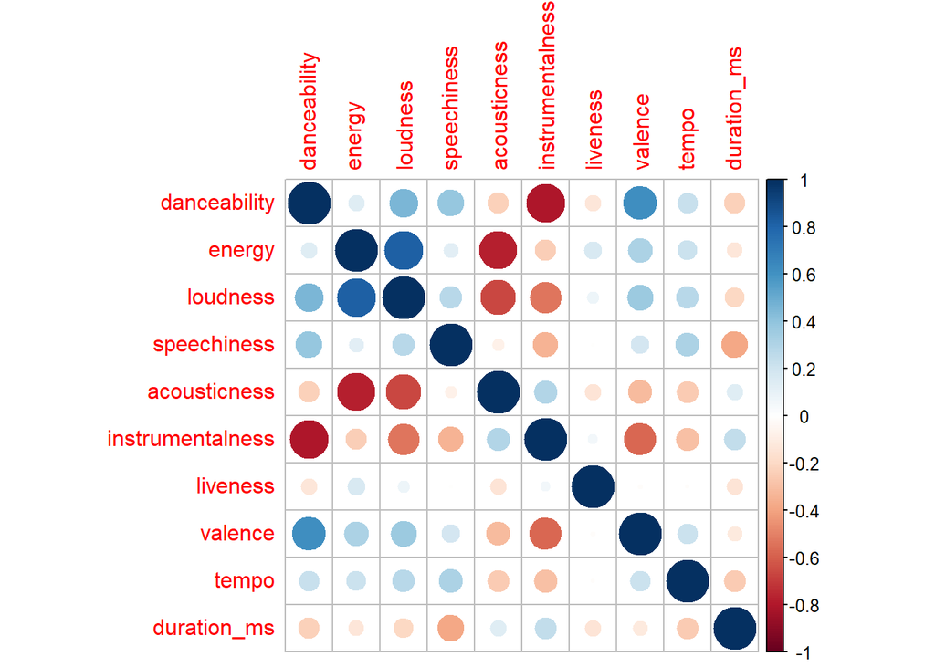

```r
spotify %>%
  select(where(is.numeric)) %>%
  cor() %>%
  corrplot()
```

These are the main correlations in the data set and we can take a further look into them.

### Energy and Loudness

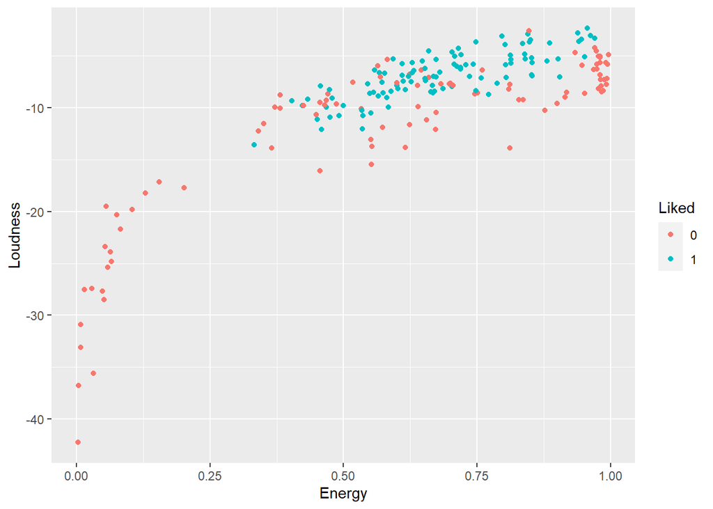

```r
ggplot(data = spotify, aes(x = energy, y = loudness, color = liked)) +
  geom_point() +
  labs(x = "Energy", y = "Loudness", color = "Liked")
```

This is an obvious correlation, the louder a song is the more energy it will have. It seems to have a slow energy increase at first. It seems that Vergnou likes songs that have more energy to them.

### Danceability and Valence

Another correlation to take look at:

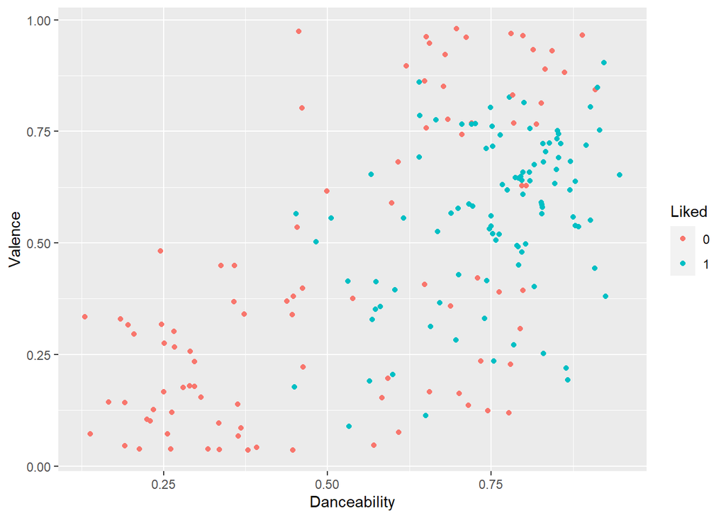

```r
ggplot(data = spotify, aes(x = danceability, y = valence, color = liked)) +
  geom_point() +
  labs(x = "Danceability", y = "Valence", color = "Liked")
```

It seems that Vergnou likes songs that have more danceability to them. There is not one liked song that has a danceability score lower than .45

### Instrumentalness and Danceability

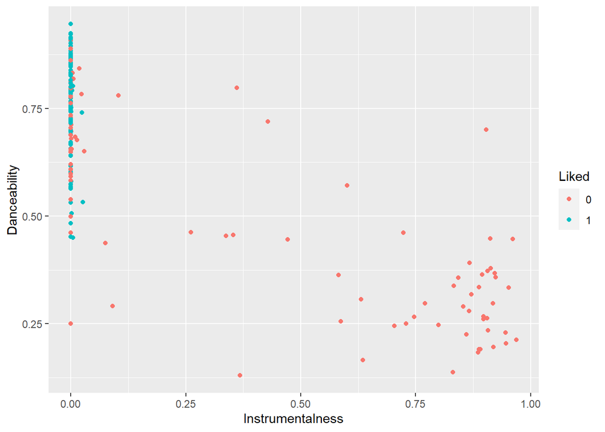

```r
ggplot(data = spotify, aes(x = instrumentalness, y = danceability, color = liked)) +
  geom_point() +
  labs(x = "Instrumentalness", y = "Danceability", color = "Liked")
```

It is quite visible how these are negatively correlated. All the liked values are shoved way to the side and we can barely tell what is going on. As danceability increases, we have no increase for instrumentalness.

## Distribution of Outcome Variable

It is important to check that we have a balanced data set so that we do not risk putting model performance in jeopardy.

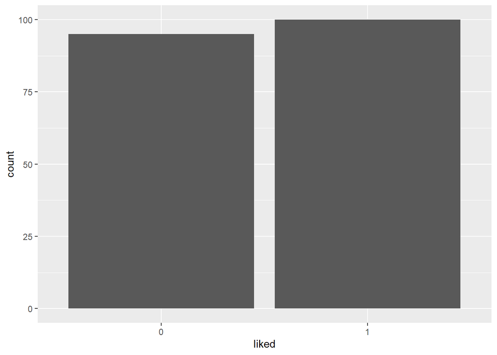

```r
spotify %>%
  ggplot(aes(x=liked)) +
  geom_bar()
```

*Note: 0 is disliked and 1 is liked.*

We can see that there are 95 disliked songs and 100 liked songs. This should not affect our model performance too much.

### Intrumentalness

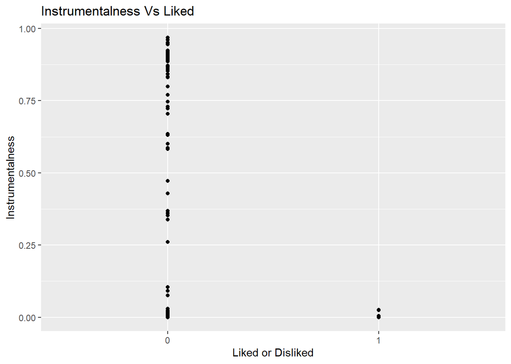

```r
ggplot(spotify, aes(x=liked,y=instrumentalness)) +
  geom_point()+
  labs(y = "Instrumentalness", x = "Liked or Disliked", title = "Instrumentalness Vs Liked")
```

We can see from the plot that tracks listed as disliked tend to have a higher instrumentalness. This variable will allow for the model to see that Vergnou does not like instrumental music. This makes sense why it would be such an important predictor variable. I would have loved to do this project on my own music taste but I plan to recreate this project on my own time in the future.

### Duration_ms

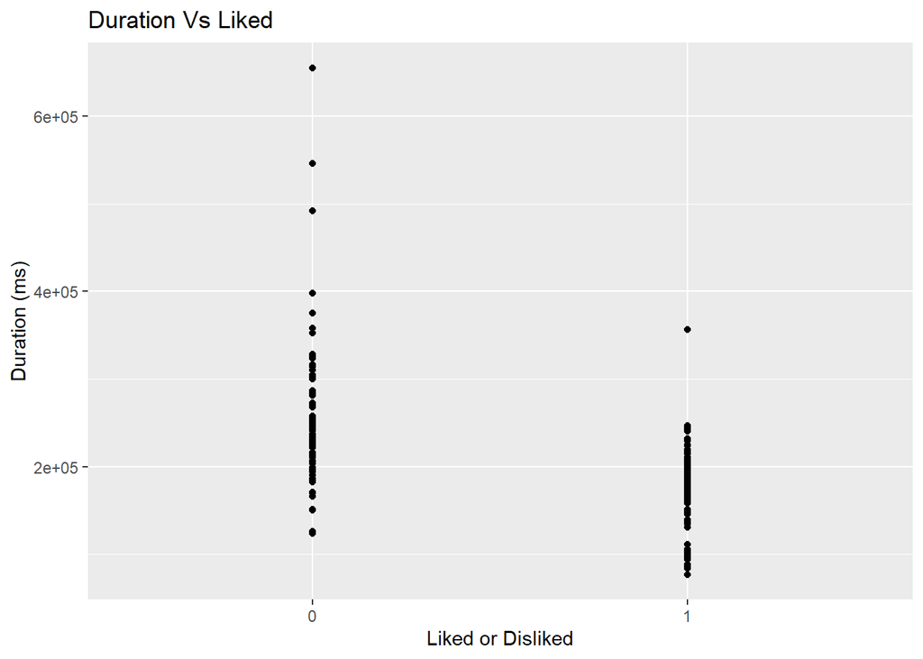

```r
ggplot(spotify, aes(x=liked,y=duration_ms)) +
  geom_point()+
  labs(y = "Duration (ms)", x = "Liked or Disliked", title = "Duration Vs Liked")
```

From the plot, it seems that Vergnou likes shorter songs more than longer songs. I wonder if he even realized this was the case when he was creating the playlists for the data set. Regardless, it is still interesting to see how specific varaibles are looked at in our model.

### Mode

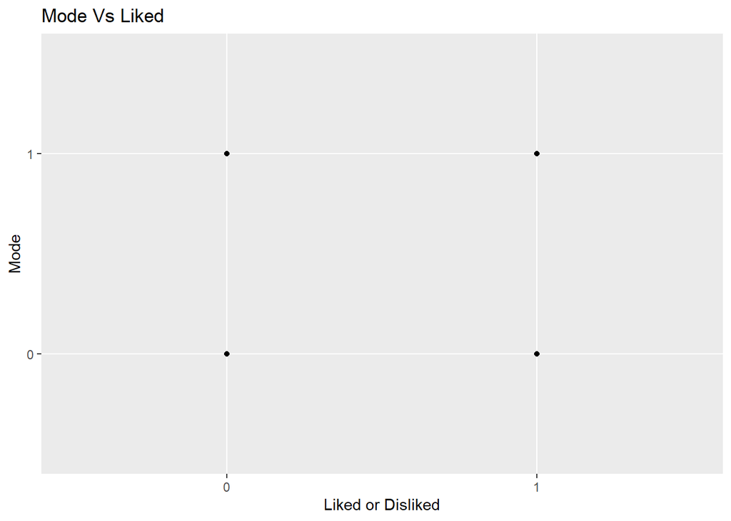

```r
ggplot(spotify, aes(x=liked,y=mode)) +
  geom_point()+
  labs(y = "Mode", x = "Liked or Disliked", title = "Mode Vs Liked")
```

From this plot, we see that nothing is really going on here. This leads me to believe it will be a pretty poor predictor for `liked` and so I will choose to remove it from the data set and continue my predictive model without it.

# Data Splitting and Cross Validation

We split the data stratifying on the variable `liked` to ensure that the proportion of observations with each level of our outcome variable is the same. This is a random process so we set a seed in the computer to make sure we can reproduce our results. We are using the library `tidymodels()` which allows us to make an initial split of the data. We can then take the split data and assign a specified proportion (80%) of it to a training set and the rest of the data to a testing set. The training set will be used to train our models on the data the we have. Once we have chosen our best fit model we can test its accuracy on the testing set.

## Remove Mode

I decided to remove the variable `mode` because it had a value of 1 or 0 for major or minor. It seems to not be the best predictor so I removed it.

```r
spotify <- spotify %>%
  subset(select = -mode)
```

## Split the Data

```r
set.seed(42) # The meaning of life (Hitchhikers Guide)

spotify_split <- initial_split(spotify, prop = 0.80,
                                strata = liked)
spotify_train <- training(spotify_split)
spotify_test <- testing(spotify_split)
```

Dimensions of our training set:

```r
dim(spotify_train)
```

```
## [1] 156  13
```

Dimensions of our testing set:

```r
dim(spotify_test)
```

```
## [1] 39 13
```

We have a pretty small data set so this makes sense. Spotify as an entire platform does this with every song that an individual has listened to. This is the purpose of being able to like a song on Spotify. However, if you are like me and only add songs to playlists, they keep track of how often you listen to a track.

## K-fold Cross-Validation

Resampling techniques such as k-fold cross-validation allow us to test our model to its fullest ability. If we chose not to resample we could face over fitting our model. K-fold cross-validation involves dividing the data into k subsets, using k-1 of them to train the model. The final subset is then used to evaluate the model performance. This process is repeated k times with each subset serving as the test set exactly one time. This reduces the risk of over-fitting/under-fitting.

We need 3 things to use k-fold cross-validation:

1. a workflow w/ one or more arguments marked for tuning.
2. a vfold_cv: resample object of the cross-validation; essentially set number of folds.
3. a tune grid: set of predefined values for each of the hyperparameters.

```r
set.seed(42)
spotify_folds <- vfold_cv(spotify_train, v=5, strata='liked')
```

Since our data set is relatively small, I chose to use 5 folds in our cross-validation to ensure no over-fitting occurs. I also chose to stratified sampling on `liked` so that each fold has a representative sample of the outcome variable.

# Model Fitting

To begin model fitting, I made a recipe that contained all the predictor variables. We have some categorical values that are pre-dummycoded in the dataset. I am not sure how the recipe will treat these values so I ran `step_dummy()` anyways. I also normalized all my predictor variables.

## How do we analyze our models?

For a classification model, we want to look at the `roc_auc` or `accuracy` to determine model performance. The `roc_auc` measures the area under the ROC (Receiver Operating Characteristic) curve, which plots the true positive rate against the false positive rate for different threshold values. ROC AUC can be a useful metric when the classes in your problem are imbalanced or when you care more about correctly identifying one class over the other. We can also check our model accuracy which is simply a measure of how many correct predictions were made when compared to the true data.

We are mostly going to be looking at the `accuracy` measurement to analyze these models because our data set is relatively small and balanced.

## Create a Recipe

The perk of using `tidymodels()` is that we can create one recipe and use it for all of our models.

```r
spotify_recipe <- recipe(liked ~ ., data=spotify_train) %>%
  step_dummy(all_nominal_predictors()) %>%
  step_normalize(all_predictors())
```

## Logistic Regression

First, we set up our logistic regression model using `logistic_reg()`. We set the engine to `glm` and the mode to `classification`. We need to make sure to specify that it is a classification model and **not** a regression model.

```r
# Set model
log_mod <- logistic_reg() %>%
  set_engine('glm') %>%
  set_mode('classification')
```

Then, we can set up workflow and add the logistic regression model:

```r
# Create workflow
log_wkflow <- workflow() %>%
  add_model(log_mod) %>%
  add_recipe(spotify_recipe)
```

Finally, we can fit the model to our **folded** data:

```r
#log_fit <- fit_resamples(log_wkflow, spotify_folds)
#save(log_fit, file='log_fit.rda')
load('log_fit.rda')
```

*code is commented out because we will save and load it all in.*

Collecting metrics based on **folded** data:

```r
collect_metrics(log_fit)
```

```
## # A tibble: 2 × 6
##   .metric  .estimator  mean     n std_err .config
##   <chr>    <chr>      <dbl> <int>   <dbl> <chr>
## 1 accuracy binary     0.846     5  0.0191 Preprocessor1_Model1
## 2 roc_auc  binary     0.894     5  0.0201 Preprocessor1_Model1
```

About 84% `accuracy` and a `roc_auc` of .89. These are pretty good metrics for a first model, but lets see what else we can do by playing around with the logistic regression model.

We can try to fit the model to the **training set**, not just the folded data.

```r
#log_fit_train <- fit(log_wkflow, spotify_train)
#save(log_fit_train, file='log_fit_train.rda')
load('log_fit_train.rda')
```

Let’s assess the model results with the **training set** data:

Let’s take a look at the prediction probabilities for our song data. Remember 0 is for disliked and 1 is liked.

```r
predict(log_fit_train, new_data = spotify_train, type = 'prob')
```

```
## # A tibble: 156 × 2
##    .pred_0  .pred_1
##      <dbl>    <dbl>
##  1   1     2.22e-16
##  2   0.942 5.82e- 2
##  3   1     2.22e-16
##  4   1     2.22e-16
##  5   0.999 1.35e- 3
##  6   1.00  1.35e- 9
##  7   0.574 4.26e- 1
##  8   0.964 3.56e- 2
##  9   1     2.22e-16
## 10   1     2.22e-16
## # … with 146 more rows
```

```r
augment(log_fit_train, new_data = spotify_train) %>%
  conf_mat(truth = liked, estimate = .pred_class)
```

```
##           Truth
## Prediction  0  1
##          0 72  3
##          1  4 77
```

A heat map of the confusion matrix:

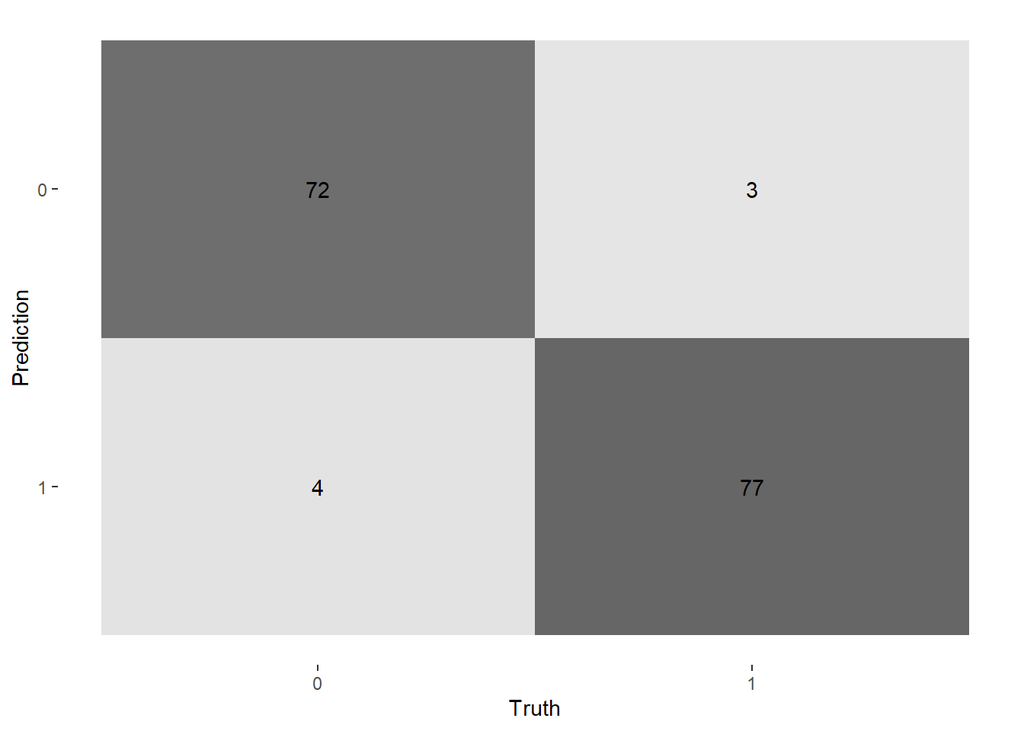

```r
augment(log_fit_train, new_data = spotify_train) %>%
  conf_mat(truth = liked, estimate = .pred_class) %>%
  autoplot(type = "heatmap")
```

This is a nice visual to see where the true values and the predictions were the same. We have 4 false positives and 3 false negatives.

Lastly we can check the `accuracy` with the training set model:

```r
log_mod_results <- augment(log_fit_train, new_data = spotify_train) %>%
  accuracy(truth = liked, estimate = .pred_class)

log_mod_results
```

```
## # A tibble: 1 × 3
##   .metric  .estimator .estimate
##   <chr>    <chr>          <dbl>
## 1 accuracy binary         0.955
```

Wow! Our accuracy went up to 95% when we fit the model to all the training set data.

## Random Forest

First, we set up our random forest model tuning on `mtry`, `trees`, and `min_n`. We set mode as classification because we are predicting a categorical value.

```r
rf_mod <- rand_forest(mtry = tune(),trees = tune(),min_n = tune()) %>%
  set_engine('ranger',importance = "impurity") %>%
  set_mode('classification')
```

Then, we set up my workflow using the mode we just created above as well as our recipe:

```r
rf_wkflow <- workflow() %>%
  add_recipe(spotify_recipe) %>%
  add_model(rf_mod)
```

Now, we set up a regular grid so that each hyper parameter has a preset value to run off. I chose `mtry` to range from 1 to 12 because that is how many parameters we have in the model. I chose a range of 100 to 500 `trees` because I do not have a very large data set and I still wanted to be able to have a concise model. I chose `min_n` to be anywhere from 5 to 50 because our model is not that big.

```r
rf_grid <- grid_regular(mtry(range=c(1,12)),
                        trees(range=c(100,500)),
                        min_n(range=c(5,50)),
                        levels = 8)
rf_grid
```

```
## # A tibble: 512 × 3
##     mtry trees min_n
##    <int> <int> <int>
##  1     1   100     5
##  2     2   100     5
##  3     4   100     5
##  4     5   100     5
##  5     7   100     5
##  6     8   100     5
##  7    10   100     5
##  8    12   100     5
##  9     1   157     5
## 10     2   157     5
## # … with 502 more rows
```

Lastly, we can fit our random forest model:

```r
#rf_tune <- rf_wkflow %>%
#  tune_grid(resamples = spotify_folds,
#            grid = rf_grid)
#save(rf_tune, file='rf_tune.rda')
load('rf_tune.rda')
```

*Commented code is loaded in.*

Lets plot the tuned random forest model and analyze:

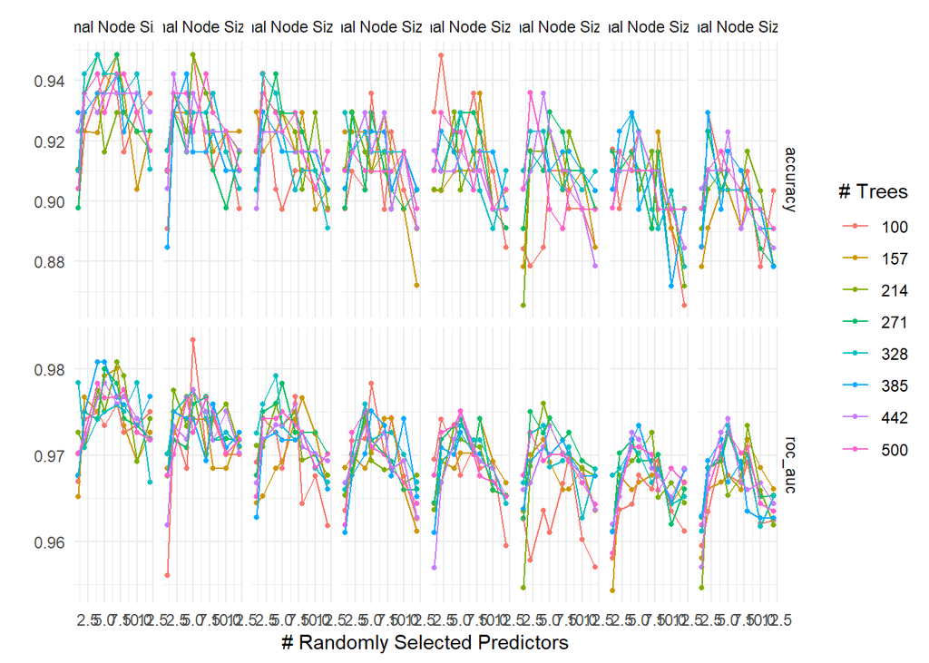

```r
autoplot(rf_tune) + theme_minimal()
```

This plot is split into accuracy(top) and roc_auc(bottom). There are 8 models being shown here and this is because we specified 8 levels in our code. Each line shows a randomly selected predictor and the color represents how many trees that predictor followed in a given model.

Let’s check our metrics for the best performed model:

```r
show_best(rf_tune, metric = 'accuracy')
```

```
## # A tibble: 5 × 9
##    mtry trees min_n .metric  .estimator  mean     n std_err .config
##   <int> <int> <int> <chr>    <chr>      <dbl> <int>   <dbl> <chr>
## 1     7   157     5 accuracy binary     0.949     5  0.0130 Preprocessor1_Model…
## 2     4   271     5 accuracy binary     0.949     5  0.0130 Preprocessor1_Model…
## 3     7   271     5 accuracy binary     0.949     5  0.0130 Preprocessor1_Model…
## 4     4   328     5 accuracy binary     0.949     5  0.0130 Preprocessor1_Model…
## 5     5   100    11 accuracy binary     0.949     5  0.0130 Preprocessor1_Model…
```

```r
show_best(rf_tune, metric = 'roc_auc')
```

```
## # A tibble: 5 × 9
##    mtry trees min_n .metric .estimator  mean     n std_err .config
##   <int> <int> <int> <chr>   <chr>      <dbl> <int>   <dbl> <chr>
## 1     5   100    11 roc_auc binary     0.983     5  0.0108 Preprocessor1_Model0…
## 2     7   214     5 roc_auc binary     0.981     5  0.0114 Preprocessor1_Model0…
## 3     4   385     5 roc_auc binary     0.981     5  0.0124 Preprocessor1_Model0…
## 4     5   385     5 roc_auc binary     0.981     5  0.0132 Preprocessor1_Model0…
## 5     7   157     5 roc_auc binary     0.980     5  0.0120 Preprocessor1_Model0…
```

## K-Nearest Neighbors

First, we will set up the model tuning `neighbors`:

```r
knn_mod <-
  nearest_neighbor(
    neighbors = tune(),
    mode = 'classification') %>%
  set_engine('kknn')
```

Then, we can set up the workflow:

```r
knn_wkflow <- workflow() %>%
  add_model(knn_mod) %>%
  add_recipe(spotify_recipe)
```

Now, we will need to set up a tuning grid:

```r
knn_grid <- grid_regular(neighbors(range = c(1,15)),levels = 10)
knn_grid
```

```
## # A tibble: 10 × 1
##    neighbors
##        <int>
##  1         1
##  2         2
##  3         4
##  4         5
##  5         7
##  6         8
##  7        10
##  8        11
##  9        13
## 10        15
```

Finally, we fit and tune k-nearest neighbors model:

```r
#knn_tune <- knn_wkflow %>%
#  tune_grid(resample=spotify_folds,
#            grid=knn_grid)
#save(knn_tune, file='knn_tune.rda')
load('knn_tune.rda')
```

*Again, I commented out the code so that it does not try to knit.*

Lets plot the model and analyze:

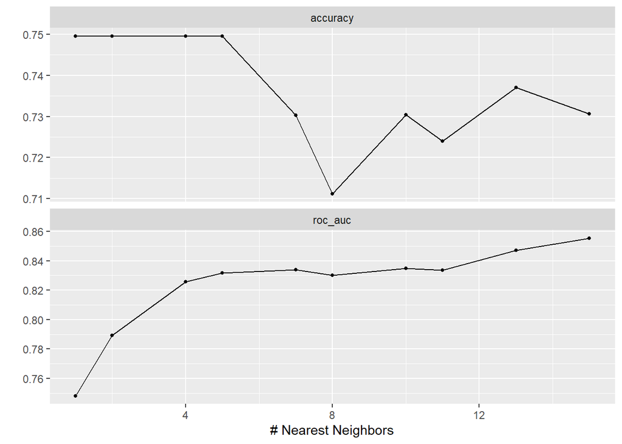

```r
autoplot(knn_tune)
```

Assessing model performance:

```r
show_best(knn_tune, metric = 'roc_auc')
```

```
## # A tibble: 5 × 7
##   neighbors .metric .estimator  mean     n std_err .config
##       <int> <chr>   <chr>      <dbl> <int>   <dbl> <chr>
## 1        15 roc_auc binary     0.855     5  0.0287 Preprocessor1_Model10
## 2        13 roc_auc binary     0.847     5  0.0324 Preprocessor1_Model09
## 3        10 roc_auc binary     0.835     5  0.0327 Preprocessor1_Model07
## 4         7 roc_auc binary     0.834     5  0.0341 Preprocessor1_Model05
## 5        11 roc_auc binary     0.834     5  0.0338 Preprocessor1_Model08
```

```r
show_best(knn_tune, metric = 'accuracy')
```

```
## # A tibble: 5 × 7
##   neighbors .metric  .estimator  mean     n std_err .config
##       <int> <chr>    <chr>      <dbl> <int>   <dbl> <chr>
## 1         1 accuracy binary     0.750     5  0.0476 Preprocessor1_Model01
## 2         2 accuracy binary     0.750     5  0.0476 Preprocessor1_Model02
## 3         4 accuracy binary     0.750     5  0.0476 Preprocessor1_Model03
## 4         5 accuracy binary     0.750     5  0.0476 Preprocessor1_Model04
## 5        13 accuracy binary     0.737     5  0.0297 Preprocessor1_Model09
```

While this model does not perform as well as the random forest or logistic regression models, it’s worth noting that the best accuracy model has 1 to 5 neighbors, and the best roc_auc model has 15 neighbors. If I had to choose between these two models, I would prefer the one with 15 neighbors since roc_auc takes into account the trade-offs between precision and recall, whereas accuracy only considers the number of correct predictions. This decision is based on the table provided. Additionally, considering the graph posted above, we can see that the model with 13 neighbors has the second highest roc_auc and the fifth highest accuracy. If I were to choose k-Nearest Neighbors as my model, I would probably choose 13 neighbors to continue my predictions.

## Decision Tree

Creating a decision tree specification using rpart:

```r
tree_spec_mod <- decision_tree() %>%
  set_engine("rpart") %>%
  set_mode("classification")
```

Fitting the model:

```r
tree_spec_fit <- tree_spec_mod %>%
  fit(liked ~ .,data=spotify_train) %>%
  step_rm(mode)
```

Visualize the decision tree:

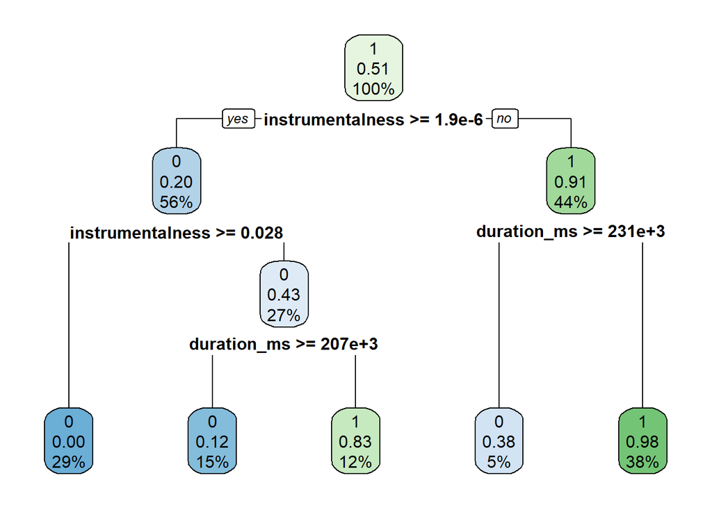

```r
tree_spec_fit %>%
  extract_fit_engine() %>%
  rpart.plot(roundint = FALSE)
```

Checking the confusion matrix and accuracy of the train data:

```r
augment(tree_spec_fit, new_data = spotify_train) %>%
  conf_mat(truth = liked, estimate = .pred_class)
```

```
##           Truth
## Prediction  0  1
##          0 72  6
##          1  4 74
```

We can visualize this better with a heat map:

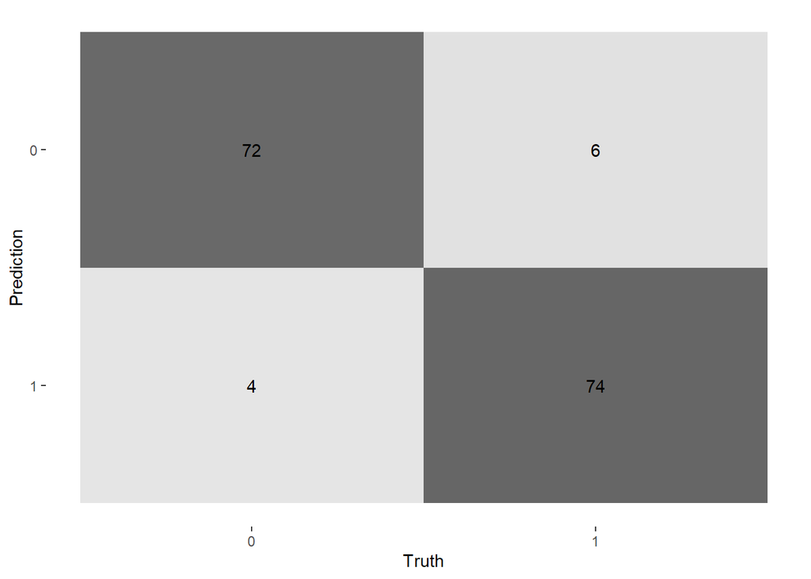

```r
augment(tree_spec_fit, new_data = spotify_train) %>%
  conf_mat(truth = liked, estimate = .pred_class) %>%
  autoplot(type = "heatmap")
```

Looking at this heat map, I am guessing that our logistic model might be a little better than this tree specification model. Lets actually check the accuracy of this simple model.

```r
tree_spec_accuracy <- augment(tree_spec_fit, new_data = spotify_train) %>%
  accuracy(truth = liked, estimate = .pred_class)
tree_spec_accuracy
```

```
## # A tibble: 1 × 3
##   .metric  .estimator .estimate
##   <chr>    <chr>          <dbl>
## 1 accuracy binary         0.936
```

As I guessed, the model accuracy for the tree_spec_fit is about 93%, whereas the logistic train data model is about 95% accurate.

Now, lets create a workflow and `tune()` on `cost_complexity()`:

```r
tree_spec_wkflow <- workflow() %>%
  add_model(tree_spec_mod %>%
  set_args(cost_complexity=tune())) %>%
  add_recipe(spotify_recipe)
```

Setting up a grid to use with tuning:

```r
tree_spec_grid <- grid_regular(cost_complexity(range=c(-3,-1)), levels = 10)
tree_spec_grid
```

```
## # A tibble: 10 × 1
##    cost_complexity
##              <dbl>
##  1         0.001
##  2         0.00167
##  3         0.00278
##  4         0.00464
##  5         0.00774
##  6         0.0129
##  7         0.0215
##  8         0.0359
##  9         0.0599
## 10         0.1
```

Fitting and tuning our model:

```r
#tree_spec_tune <- tree_spec_wkflow %>%
#  tune_grid(resamples = spotify_folds,
#            grid = tree_spec_grid)

#save(tree_spec_tune, file="ts_tune.rda")
load("ts_tune.rda")
```

Plotting or tree specification model, which shows what cost-complexity produces the highest accuracy:

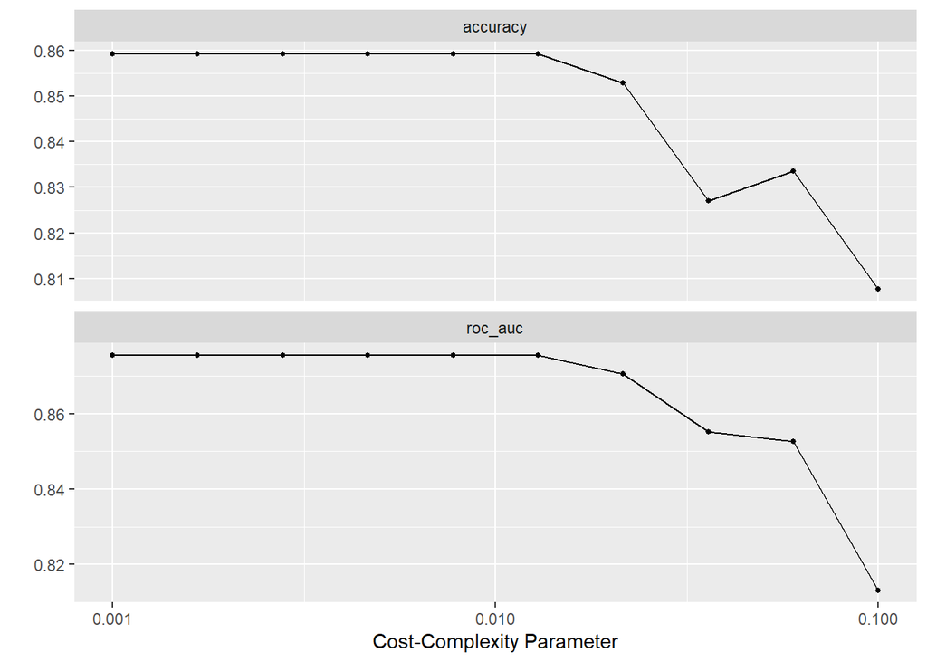

```r
autoplot(tree_spec_tune)
```

Selecting the best performing value and finalizing the workflow:

```r
best_complexity <- select_best(tree_spec_tune, metric = 'accuracy')

tree_spec_final <- finalize_workflow(tree_spec_wkflow, best_complexity)

tree_spec_final_fit <- fit(tree_spec_final, data = spotify_train)
```

Visualize that model girl:

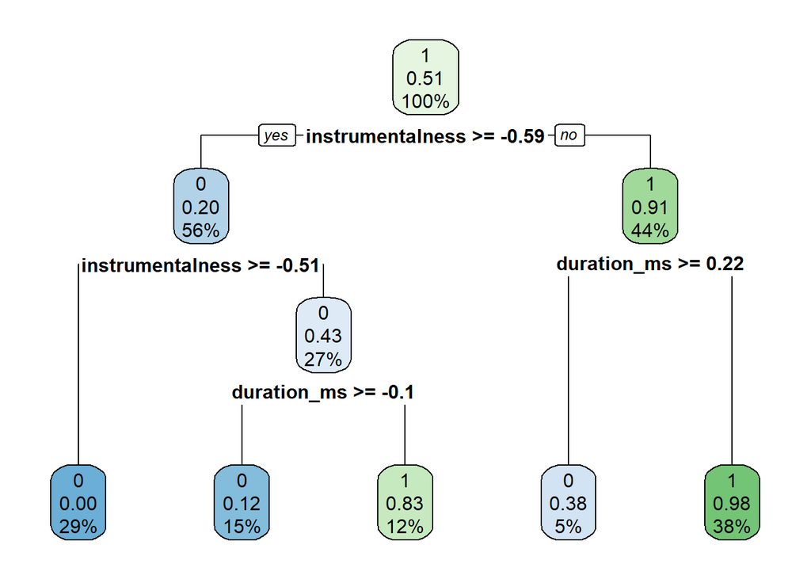

```r
tree_spec_final_fit %>%
  extract_fit_engine() %>%
  rpart.plot(roundint=FALSE)
```

Checking the accuracy of the final tuned tree specification model:

```r
tuned_tree_accuracy <- augment(tree_spec_final_fit, new_data = spotify_train) %>%
  accuracy(truth = liked, estimate = .pred_class)
tuned_tree_accuracy
```

```
## # A tibble: 1 × 3
##   .metric  .estimator .estimate
##   <chr>    <chr>          <dbl>
## 1 accuracy binary         0.936
```

The decision tree model with cost-complexity tuning had the same accuracy as the decision tree model without tuning. This could be due to the fact that our data set is not particularly complex, so adding a cost-complexity parameter did not improve the model’s performance. Additionally, it’s possible that the chosen parameter values for the cost-complexity tuning did not have a significant impact on the model’s accuracy. Overall, the decision tree model’s high accuracy indicates that it is a suitable choice for analyzing this dataset.

# Model Selection and Performance

## Model Accuracies

Constructing a table of accuracies can be a helpful way to visualize the models at hand.

```r
accuracies <- c(log_mod_results$.estimate,
                0.8459677,
                0.9485887,
                0.7495968,
                0.9358974,
                0.9358974)

models <- c("Logistic Train Data", "Logistic Fold Data", "Random Forest", "K-Nearest Neighbor","Decision Tree", "Decision Tree (tuned)")

results <- tibble(models = models, accuracies = accuracies)

results %>%
  arrange(-accuracies)
```

```
## # A tibble: 6 × 2
##   models                accuracies
##   <chr>                      <dbl>
## 1 Logistic Train Data        0.955
## 2 Random Forest              0.949
## 3 Decision Tree              0.936
## 4 Decision Tree (tuned)      0.936
## 5 Logistic Fold Data         0.846
## 6 K-Nearest Neighbor         0.750
```

Our highest performing models are Logistic Train data and Random Forest, with the former being slightly better. The Decision Tree model achieved an accuracy of about 93%, regardless of whether cost-complexity was tuned or not. The Logistic Fold data model is 11% less accurate than Logistic Train Data, and K-Nearest Neighbors is 21% less accurate than Logistic Train Data.

We will proceed to fit the Logistic Train Data model to our test set. I will also be fitting the Random Forest to our test set because it was such a close second place.

## Logistic Model Finilization

We can test the Logistic Regression model to `spotify_test`, which is our testing set.

```r
augment(log_fit_train, new_data = spotify_test) %>%
  conf_mat(truth=liked, estimate = .pred_class)
```

```
##           Truth
## Prediction  0  1
##          0 12  2
##          1  7 18
```

Lets get a better look at this confusion matrix:

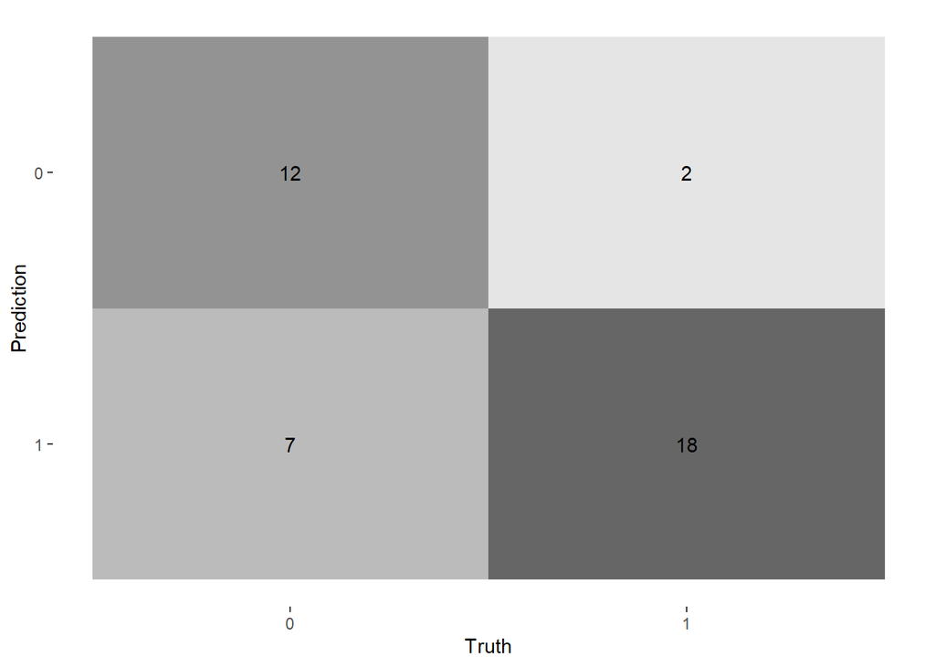

```r
augment(log_fit_train, new_data = spotify_test) %>%
  conf_mat(truth=liked, estimate = .pred_class) %>%
  autoplot(type = 'heatmap')
```

Just by looking at the confusion matrix, we can see that our model is going to perform worse than it did when we were getting accuracy on the training set. This is what I expected because the model was tested on on what it learned before. Now the model is looking at data it has never seen before. This is an issue we run into with judging based off of accuracy. The exact reason why we need to cross validate. Looking at our Logistic model that trained on the folded data, we can gain a more accurate representation of the logistic models performance.

Lets check the accuracy of this model:

```r
multi_metric <- metric_set(accuracy, sensitivity, specificity)
augment(log_fit_train, new_data = spotify_test) %>%
  multi_metric(truth = liked, estimate = .pred_class)
```

```
## # A tibble: 3 × 3
##   .metric     .estimator .estimate
##   <chr>       <chr>          <dbl>
## 1 accuracy    binary         0.769
## 2 sensitivity binary         0.632
## 3 specificity binary         0.9
```

As we expect the model performance has plummeted! This is why we are going to check the Random Forest model. I believe that the accuracy is going to be the highest and be our best final model.

## Random Forest Model Finalization

Now we will dive into, what I anticipate will be our most successful model.

First, we have to test the model with the test set, `spotify_test`:

```r
rf_best <- select_best(rf_tune, metric = 'accuracy')

rf_final <- finalize_workflow(rf_wkflow, rf_best)

rf_final_fit <- fit(rf_final, data=spotify_train)

augment(rf_final_fit, new_data=spotify_test) %>%
  accuracy(truth = liked, estimate = .pred_class)
```

```
## # A tibble: 1 × 3
##   .metric  .estimator .estimate
##   <chr>    <chr>          <dbl>
## 1 accuracy binary         0.897
```

Our model is 89.7% accurate! This is an example of why you cannot always trust the highest accuracy model based off of the training data. Also, you should always test multiple models!

Lets take a look at the confusion matrix:

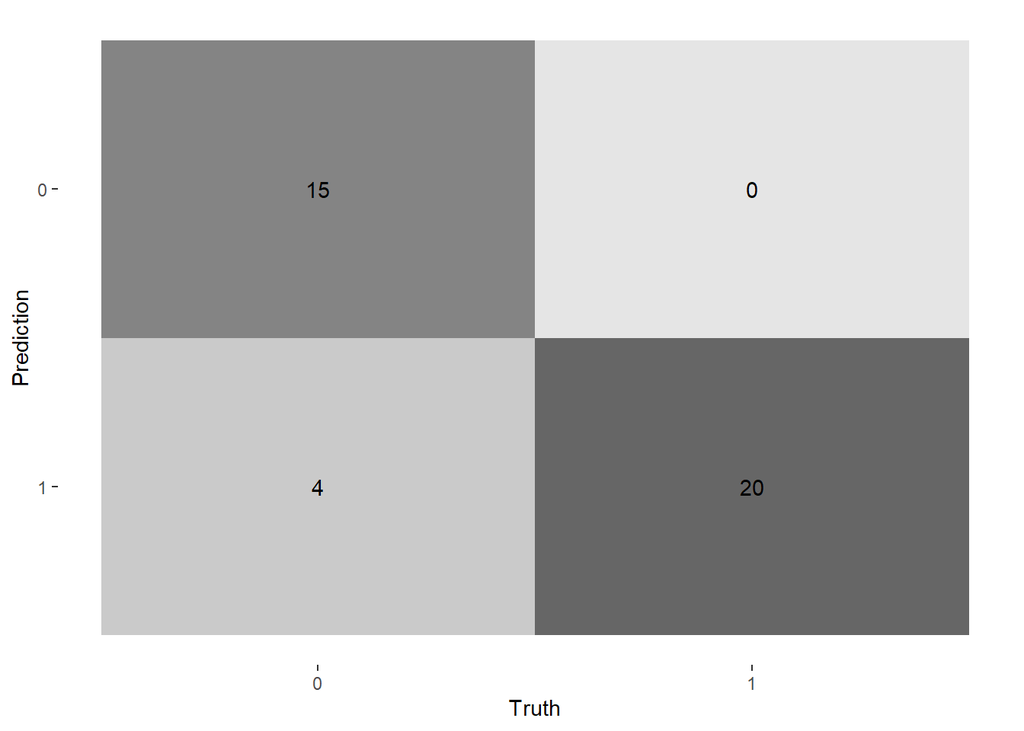

```r
augment(rf_final_fit, new_data = spotify_test) %>%
  conf_mat(truth = liked, estimate = .pred_class) %>%
  autoplot(type = 'heatmap')
```

Our model made 0 false negative predictions! It did, however, give us four false positive predictions. I suppose it is harder for our model to predict correctly whether we do not like a song than it is for it to predict that we do like a song.

Now, for sake of being complete, lets see how the model with the highest `roc_auc` performs in predicting our data:

```r
rf_best_auc <- select_best(rf_tune, metric = 'roc_auc')

rf_final_auc <- finalize_workflow(rf_wkflow, rf_best_auc)

rf_final_fit_auc <- fit(rf_final_auc, data=spotify_train)

augment(rf_final_fit_auc, new_data=spotify_test) %>%
  accuracy(truth = liked, estimate = .pred_class)
```

```
## # A tibble: 1 × 3
##   .metric  .estimator .estimate
##   <chr>    <chr>          <dbl>
## 1 accuracy binary         0.897
```

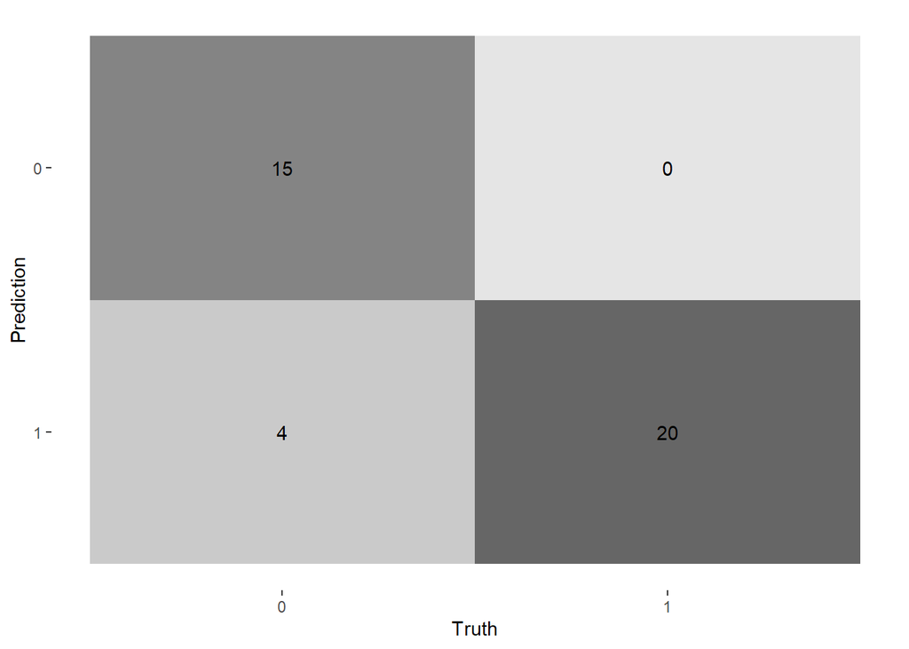

```r
augment(rf_final_fit_auc, new_data = spotify_test) %>%
  conf_mat(truth = liked, estimate = .pred_class) %>%
  autoplot(type = 'heatmap')
```

## Variable Importance

Lets see what variables were the most important in predicting whether a song was liked or disliked.

*Note that we specify importance = “impurity” in the workflow setup above; this is so that we can use `extract_fit_parsnip()` and `vip()` to create and view a variable importance plot*

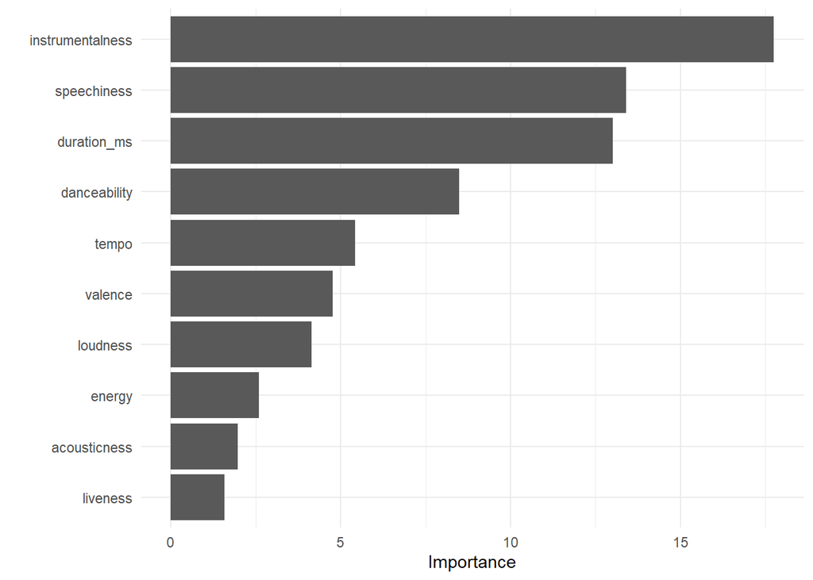

```r
rf_final_fit %>% extract_fit_parsnip() %>%
  vip() +
  theme_minimal()
```

`Instrumentalness` was the most important predictor in determining whether a track was liked or disliked by Vergnou. `Liveliness` was the least important at predicting the outcome of a track. I would conclude that this is because liveliness is pretty well distributed between both liked and disliked songs.

It is important to recall that this data is based off of the music taste of Vergnou as he is the one created it. Like I said early on I would love to create my own data set and be able to predict whether I would like a song solely based off of its attributes provided by Spotify.

Lets take a look at the roc_auc score for the prediction of a disliked song; `.pred_0`.

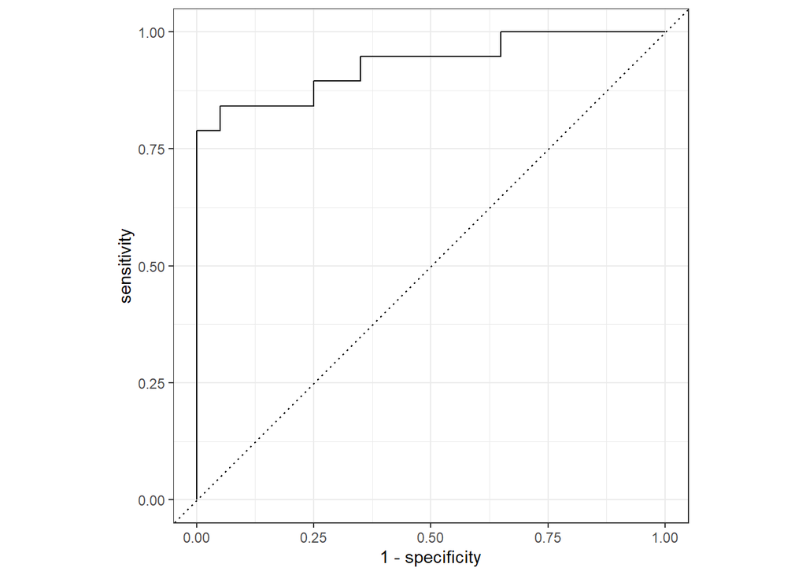

```r
roc_curve(augment(rf_final_fit_auc, new_data = spotify_test), truth = liked, .pred_0) %>%
  autoplot()
```

You can see that our model is not perfect, but to train a perfect model takes a lot more computational time and an extremely well fit model. Machine learning models are trained to make predictions based on patterns in the data used for training. However, it is often difficult to create a model that perfectly fits the data, as this can result in overfitting. To avoid overfitting, machine learning models are often trained with a certain amount of regularization, which balances the trade-off between model complexity and accuracy. This regularization helps to prevent the model from becoming too complex and overfitting the data, but may result in a less-than-perfect fit.

# Conclusion

To wrap up this model building project, I will first discuss our goals, models and outcome. Then, I will talk about any future projects and how I would continue to work on this model. Lastly, I will go over my final thoughts from the project and the class overall.

## Discussion

The purpose of this project was to build a machine learning model that, given data on selected songs, could predict whether a song was liked or disliked. We used a dataset titled [‘Spotify Recommendation’](https://www.kaggle.com/datasets/bricevergnou/spotify-recommendation) posted on Kaggle.com by Brice Vergnou, which contained 195 observations of 13 predictor variables and 1 outcome variable. The data was compiled by Vergnou and included 95 disliked songs and 100 liked songs.

We conducted some dataset analysis and found that the predictor mode was probably not the best, so we removed it and continued by splitting the data into a training set and a testing set. The training set was used to build a recipe for a total of 4 models: Logistic Regression, Random Forest, K-Nearest Neighbors, and Decision Tree.

After fitting the models, we found that the Logistic Regression and the Random Forest models had the highest accuracy, respectively. We then fit these models to our test set and were able to conclude that the Random Forest model was the best model to predict whether a song was liked or disliked. We noted that even though a model may have the highest accuracy when testing with training set data, it does not necessarily perform as well on the test set. This is why we used k-fold cross-validation. We also noted that the logistic regression model trained on the folded data was more representative of how our model would actually perform.

Our Decision Tree and K-Nearest Neighbor models, were not the best fit for our data. This is not to say that these types of model are never a useful option, it just means that the Spotify data was not good for these models. This highlights the importance testing multiple models on a data set and not being a lazy statistician.

Our Random Forest model was able to predict whether a song was liked or disliked with 89% accuracy, which I am pretty happy with for my first major machine learning project. We found that the `intrumentalness` and `liveliness` were the best and worst predictors of the outcome, respectively. We can visualize our data to know exactly why this was, but in all honesty, it depends on an individuals music taste.

## Future Research

I am interested in taking machine learning to the next step, and potentially building my own data set of music I like and do not like. I would run the songs through Spotify’s API which allows us to gather track data on any song they have available on their platform. I would be much more intrigued to see what attributes of a song are most important for me to decide if it is liked or not. I would then test it on a much larger data set of songs that I honestly have never listened to.

Additionally, my father works in the tech industry and is always asking me about building statistical models for him. I would love to put my skills to the test and try a regression model, or work with a much larger data set. *Hopefully my computer can handle that.*

## Final Thoughts

This project was a great opportunity to get hands on with the R language and machine learning concepts. Being able to work with Spotify song data gave me a reason to keep working, and gave me an intrinsic pre-understanding of the data. There is still a lot to learn when it comes to machine learning, but as soon as I learn it, I hope to apply it to my future research ideas. All in all, it gave me a better understanding of a person’s music taste and will give me an extra thing to think about whenever I find new songs.